# CAWC Arrivals Report

Kendra Lyons

2/2/2022

## Data Dates: 1/26/21-1/20/22

## Arrivals Timelines

Throughout **2021**, arrivals at Casa Alitas Welcome Center steadily increased from just a few to more than *300 people* arriving in a single day. However, there were significant fluctuations in arrival numbers at several points in time, when policy changes at the federal level affected how border authorities in states along the Southern U.S.-Mexico border detained, deported and released individuals or groups of migrants of different nationalities. Data entrusted to staff and volunteers at Alitas illustrate these dramatic ups and downs in releases of migrants by CBP and ICE, but cannot capture the intensity of the reality on the ground; neither the uncertainty for those seeking asylum, nor the difficulty of coordinating the staff and volunteers working to offer them food, shelter, medical aid, travel assistance, information services (among other initiatives) according to a range of needs.

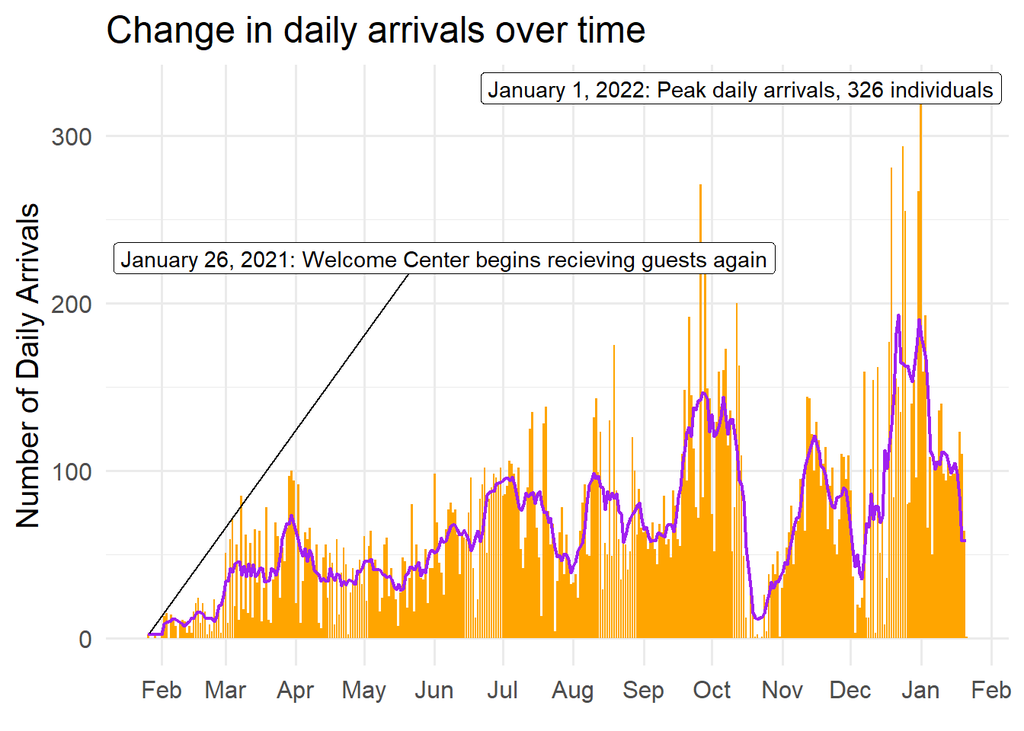

The increasing trend is even more evident in the plot below, which displays weekly arrival numbers with a linear regression line (purple) and confidence interval (shaded), and so are the abrupt and unusual drops in arrivals late in the year. Removing some noise by examining weekly rather than daily arrivals makes the scale of the fluctuations clearer. In October and December of 2021, there were several weeks with sudden and significant drops in arrivals that were *far* outside of the predictable range of usual variation. However, knowledge of potential forthcoming policy changes gleaned through networks of migrant-serving organizations or direct communication with border authorities sometimes allowed staff to prepare for large drops or spikes in arrivals.

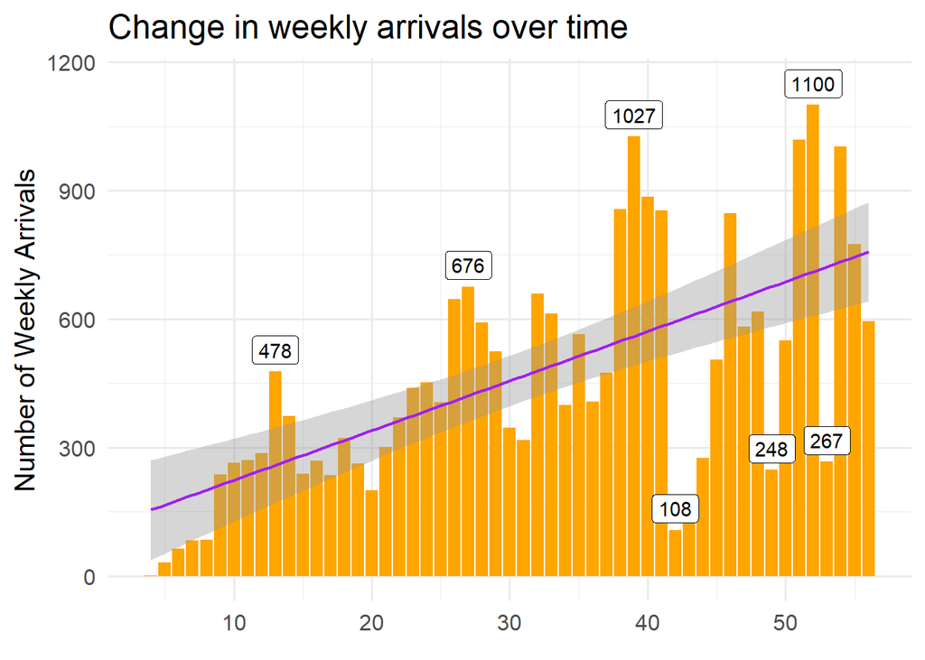

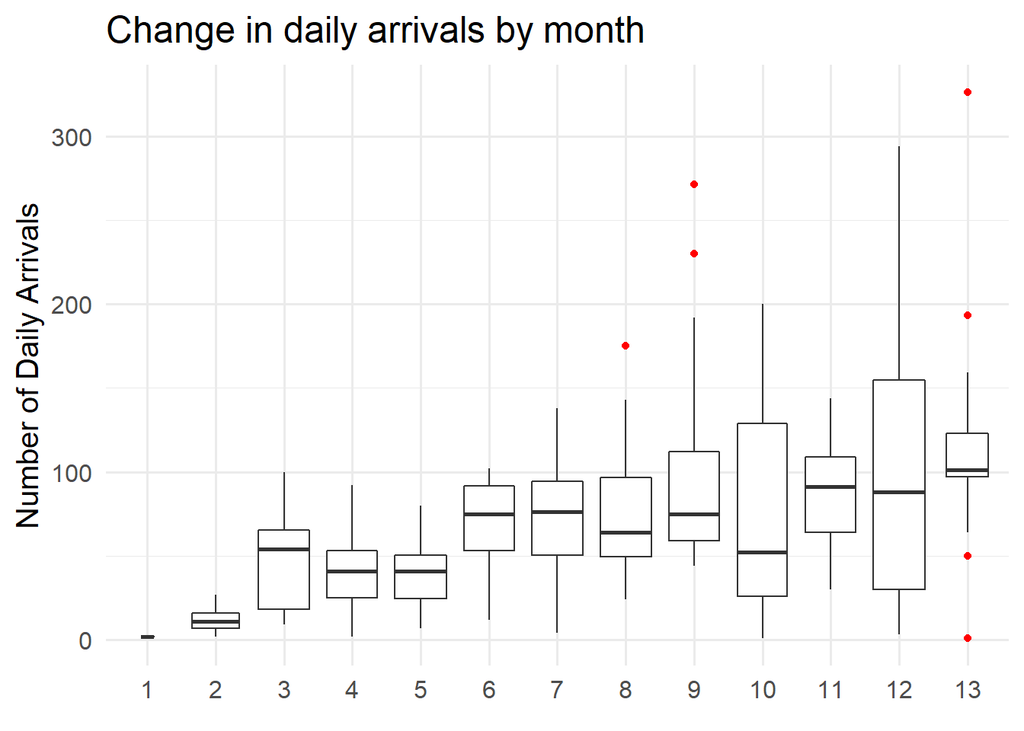

The month-by-month average of daily arrivals stayed below one-hundred throughout 2021, only barely exceeding that number in the first twenty days of 2022.

## Group Size Over Time

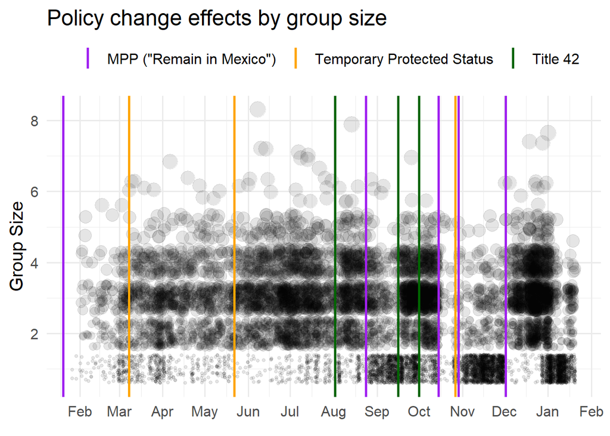

Different policies affect individual and groups of asylum seekers differently.

## Stay Length, All Guests

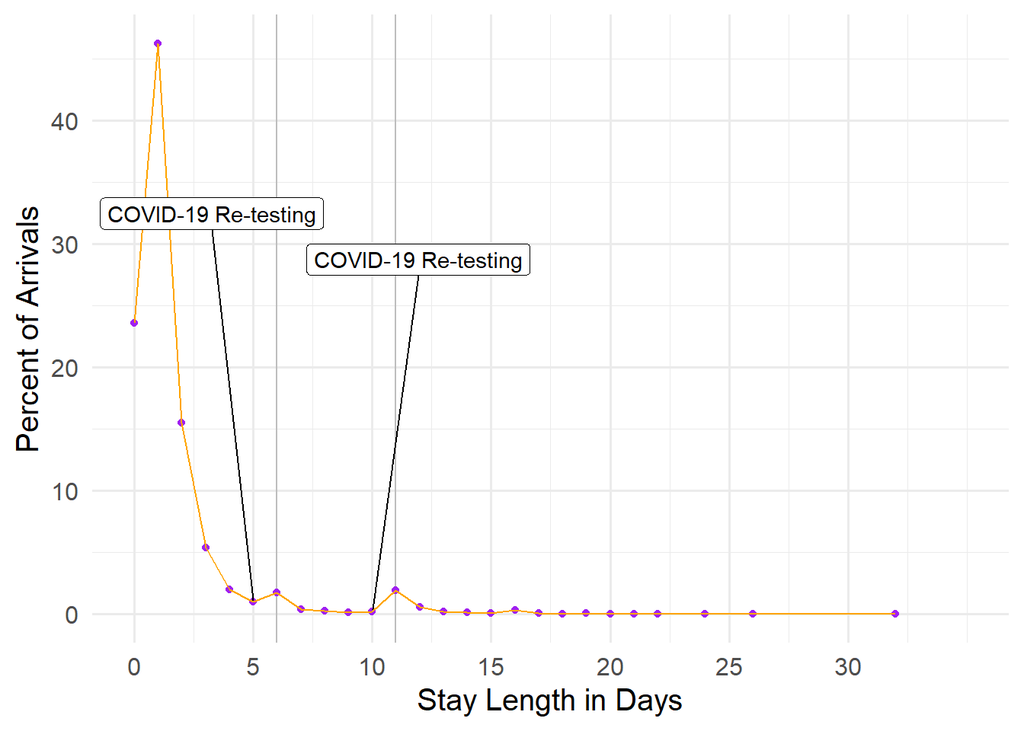

Around 70% of guests moved on after one night or less. Most likely due to quarantine and re-testing protocol when an individual or member of a group tested positive for COVID-19, less than 2% of guests had stays of 6 days or 11 days respectively.

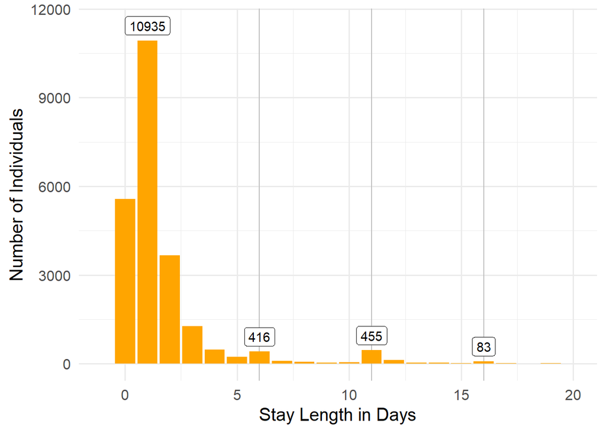

Small peaks in stay lengths of six, eleven and sixteen days occurred, usually when an individual or all members of a group tested negative for COVID-19 and were able to depart. . .

## Stay Length by Group Size

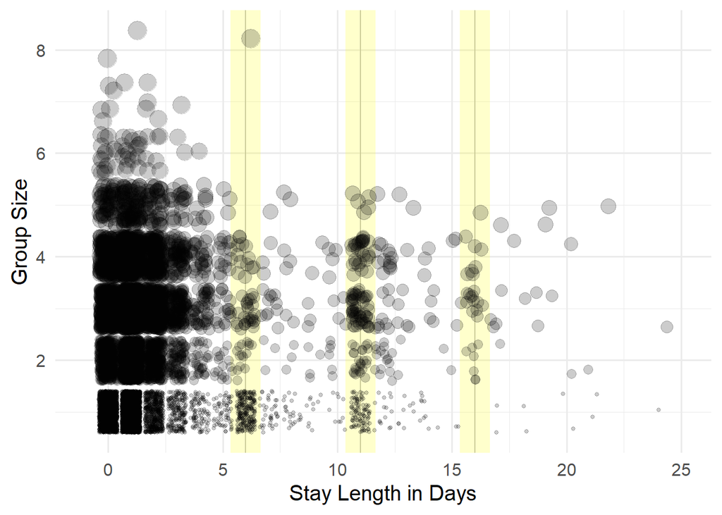

Individuals with extended stays likely due to COVID-19 most commonly left after six days. It was more common for family groups, generally quarantining together in a hotel room where it was easy to infect those who had previously tested negative, which inevitably prolonged the quarantine.

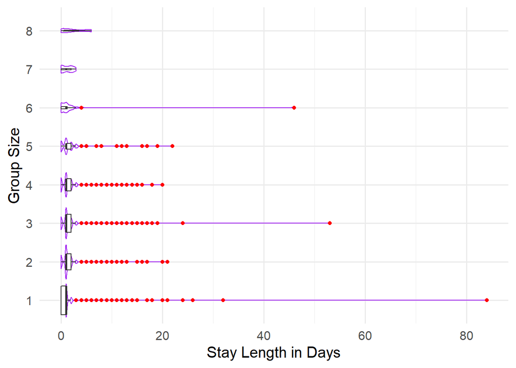

Individuals appear to move on more quickly in general, although some have extended stays due to extenuating circumstances such as issues with health, sponsors, court dates or paperwork. . . Most guests, regardless of party size, move on within a day or two.

### Further Information

- **American Immigration Council**: https://www.americanimmigrationcouncil.org/research/guide-title-42-expulsions-border
- **Arizona Public Media Video Feature**: https://www.youtube.com/watch?v=6FUyY0_exoo
- **Casa Alitas Program Website**: https://www.casaalitas.org/
- **Catholic Community Services of Southern Arizona**: https://www.ccs-soaz.org/agencies-ministries/detail/alitas-aid-for-migrant-women-and-children
- **FEMA Funds for Migrant Aid**: https://tucson.com/news/local/pima-county-uncertain-federal-funds-to-support-asylum-seekers-will-continue/article_1d07a4c8-901d-11ec-8e6c-a37e4491dcf4.html
- **Human Rights Watch**: https://www.hrw.org/news/2021/03/05/mexico-abuses-against-asylum-seekers-us-border
- **International Rescue Committee**: https://www.rescue.org/article/what-happening-us-southern-border
  - En espanol: https://www.rescue.org/article/que-esta-pasando-en-la-frontera-sur-de-estados-unidos
- **Southern Border Communities Coalition**: https://www.southernborder.org/border_lens_asylum_seekers_at_the_border
- **Tucson Sentinel**: https://www.tucsonsentinel.com/local/report/030122_casa_alitas_budget/pima-county-spending-13-million-per-month-shelter-migrants-released-by-dhs/
- **Tucson Weekly**: https://www.tucsonweekly.com/tucson/crowded-house-casa-alitas-faces-increased-pressure-as-more-migrants-seek-refugee-status/Content?oid=30449369
- **U.S. Citizenship and Immigration Services**: https://www.uscis.gov/humanitarian/refugees-and-asylum/asylum/obtaining-asylum-in-the-united-states